# Project 3 - Analyzing Valued Skills in Data Science: An Examination of LinkedIn Job Postings

Noori Selina, Zainab Oketokoun, Gavriel Steinmetz-Silber, Haig Bedros

2023-10-10

## Objective

We are attempting to use data in an effort to answer the question: **“Which are the most valued data science skills?”**

Our strategy, generally speaking, is to look at a dataset with thousands of LinkedIn job postings. We can then filter this dataset to include only data science (or data science-adjacent roles). Then, from the description of these jobs, we can extract the skills that the employers are looking for.

To be a bit more specific, we will attempt to answer two questions:

1. Overall, what are the skills that employers are lookign for in their data scientists?
2. What are the skills that the most desirable data science jobs require/prefer?

It’s worth pointing out, we originally wanted to look at another question, namely how salaries of different jobs might be associated with different skills. However, there was a lot of salary data missing, and this approach was just not feasible.

## Setting up

```r
library(DBI)
library(RMySQL)
library(dplyr)
library(stringr)
```

We start by establishing a connection to the Amazon RDS database:

```r
con <- dbConnect(RMySQL::MySQL(),
                 dbname = "linkedin_job_postings_2023",
                 host = "database-1-instance-1.cngfftmjinac.us-east-2.rds.amazonaws.com",
                 port = 3306,
                 user = "admin",
                 password = "DDbna}rt2R0h")
dbListTables(con)
```

```
## [1] "benefits"             "cleaned"              "companies"
## [4] "company_industries"   "company_specialities" "employee_counts"
## [7] "job_industries"       "job_postings"         "job_skills"
```

## Loading, cleaning the tables

```r
suppressWarnings({
query <- "SELECT * FROM benefits"
benefits <- dbGetQuery(con, query)

query <- "SELECT * FROM cleaned"
cleaned <- dbGetQuery(con, query)

query <- "SELECT * FROM companies"
companies <- dbGetQuery(con, query)

query <- "SELECT * FROM company_industries"
company_industries <- dbGetQuery(con, query)

query <- "SELECT * FROM company_specialities"
company_specialities <- dbGetQuery(con, query)

query <- "SELECT * FROM employee_counts"
employee_counts <- dbGetQuery(con, query)

query <- "SELECT * FROM job_industries"
job_industries <- dbGetQuery(con, query)

query <- "SELECT * FROM job_postings"
job_postings <- dbGetQuery(con, query)

query <- "SELECT * FROM job_skills"
job_skills <- dbGetQuery(con, query)

#closing connection
dbDisconnect(con)

})
```

```
## [1] TRUE
```

The job_postings table is of special interest. However, we are only interested in the postings for data science (or at least data-related) roles. We’ll use the grep1 function to include all titles that have the word “data” in them.

```r
ds_jobs <- job_postings %>%
  filter(grepl("Data", title, ignore.case = TRUE))

head(ds_jobs)
```

```
##       job_id company_id                             title
## 1 3586162459   69642092                Teradata Developer
## 2 3690692186      61242 Seasonal Payroll/Data Entry Clerk
## 3 3691795980    7573454                     Data Engineer
## 4 3692302089      37768  Data Scientist/ Product Analyst
## 5 3692363778    2474970         Data Analytics Consultant
## 6 3693028967   89721371             Datacenter Technician
##                                                                                                                                                                                                                                                                                                          …
## 1                                                                                                                                                                                                                                                                                                        …
## 2                                                                                                                                                                                                                                                                                                        …
## 3                                                                                                                                                                                                                                                                                                        …
## 4 Looking for candidates with experience in data science or product analyst roles with a strong background in data statistical modelling and specific experience working with Note Need some one who can work on Data Product Analyst San CA to Months Project Overview Drive analysis for Fitbit product…
## 5                                                                                                                                                                                                                                                                                                        …
## 6                                                                                                                                                                                                                                                                                                        …
##   max_salary med_salary min_salary pay_period formatted_work_type
```

[output cut: 41 more lines]

## Analysis

### Part 1: A look at Views

Soon, we will take a look at all data science-related roles. In this section, we take a slightly differennt approach. After all, we are looking for the most desirable data science skills. Perhaps, then, we can look at the most desirable jobs and see which skills are associated with those jobs. There are different ways to rank the desirability of jobs. We opted to think about views–where presumably a job is more desirable if the posting received more views.

The LinkedIn dataset is sparse; despite the “skills_desc” column, it is not entirely obvious what skills are associated with most jobs. As such, we will work to extract the skills from the postings’ descriptions. To accomplish this, we need to match words in the descriptions to words that refer to skills. We took part of an html document from a website that discusses resume skills: https://enhancv.com/resume-skills/

```r
library(rvest)

html_content <- read_html('https://raw.githubusercontent.com/hbedros/data607_prj3/gss/enhancv_excerpt.html')
li_items <- html_content %>%
  html_nodes("li") %>%
  html_text() %>%
  str_squish()   #because there is otherwise \n\n at the end of lines

li_items = tolower(li_items)

sample(li_items, 10)
```

```
##  [1] "goal setting"
##  [2] "leadership"
##  [3] "understanding different perspectives"
##  [4] "angular"
##  [5] "preparation"
##  [6] "fostering a sense of ownership and confidence"
##  [7] "cloud infrastructure"
##  [8] "influence"
##  [9] "critical thinking:"
## [10] "confidence"
```

Now we have this collection of skills. We need a function to extract matches from individual job postings:

```r
extract_skills <- function(description) {
  description <- tolower(description) #to match li_items case
  skills <- unlist(strsplit(description, "\\s+"))  #splitting using \\s, turn to vector
  skills <- skills[skills %in% li_items]  #filtering for skills in skills_list
  return(paste(unique(skills), collapse = ", "))  #combine matches into one string
}
```

Now we can apply this function, and create a new column in the dataframe with the extracted skills. While we’re at it, we will remove columns from the dataframe that aren’t as relevant to our analysis and add the company name for clarity.

```r
ds_jobs$skills <- sapply(ds_jobs$description, extract_skills, USE.NAMES = FALSE)
ds_jobs_clean <- ds_jobs[c("job_id", "company_id", "title", "views", "skills")] %>%
  left_join(select(companies, company_id, name), by = "company_id") %>%
  relocate(name, .after = 'company_id') %>%
  rename(company = name) %>%
   select(-company_id)

head(ds_jobs_clean, 10)
```

```
##        job_id                     company
## 1  3586162459                Sapience Inc
## 2  3690692186  Universal Screen Arts Inc.
## 3  3691795980                        <NA>
## 4  3692302089 Milestone Technologies Inc.
## 5  3692363778                    DiLytics
## 6  3693028967              CatalystVM LLC
## 7  3693040943       TekValue IT Solutions
## 8  3693041960            Publicis Sapient
## 9  3693043664       Premier International
## 10 3693043742            Publicis Sapient
##                                             title views
## 1                              Teradata Developer    56
## 2               Seasonal Payroll/Data Entry Clerk   325
## 3                                   Data Engineer   101
```

[output cut: 18 more lines]

A peek at the dataframe reveals a wide range of skills. Again, however, we are only interested in the postings that had a lot of views–these reflect the most desirable roles which plausibly might demand the most desirable skills. Let’s look at only the top 25% of listings

```r
upper_quart <- quantile(ds_jobs_clean$views, 0.75, na.rm = TRUE)

many_views <- ds_jobs_clean %>%
  filter(views >= upper_quart)

many_views
```

```
##        job_id                         company
## 1  3690692186      Universal Screen Arts Inc.
## 2  3693040943           TekValue IT Solutions
## 3  3693043839            Publix Super Markets
## 4  3693044837                  Insight Global
## 5  3693045284                   Roth Staffing
## 6  3693045603      Vision Technology Services
## 7  3693045756   Irvine Technology Corporation
## 8  3693045914                 The Judge Group
## 9  3693046487                      SSi People
## 10 3693046569                The CARIAN Group
## 11 3693046734                        LCG Inc.
## 12 3693047014                       MethodHub
## 13 3693047232                     LTIMindtree
## 14 3693047544                 Ztek Consulting
```

[output cut: 361 more lines]

Let’s see which skills appear the most using tidytext:

```r
library(tidytext)
skills_count <- many_views %>%
  unnest_tokens(word, skills) %>%
  count(word, sort = TRUE)

skills_count
```

```
##                word  n
## 1     communication 36
## 2               sql 36
## 3     understanding 31
## 4            python 20
## 5             excel 14
## 6        leadership 13
## 7            vision 13
## 8          research 12
## 9      organization 10
## 10          tableau  9
## 11    documentation  7
## 12       evaluation  7
## 13        integrity  7
## 14     presentation  6
```

[output cut: 27 more lines]

The results are telling. In the most viewed (and therefore, perhaps, desirable) data science-related postings, many of the skills are not technical at all! In fact, of the top 3 skills, 2 are “communication” and “understanding.” We can visualize this nicely with a wordcloud as well.

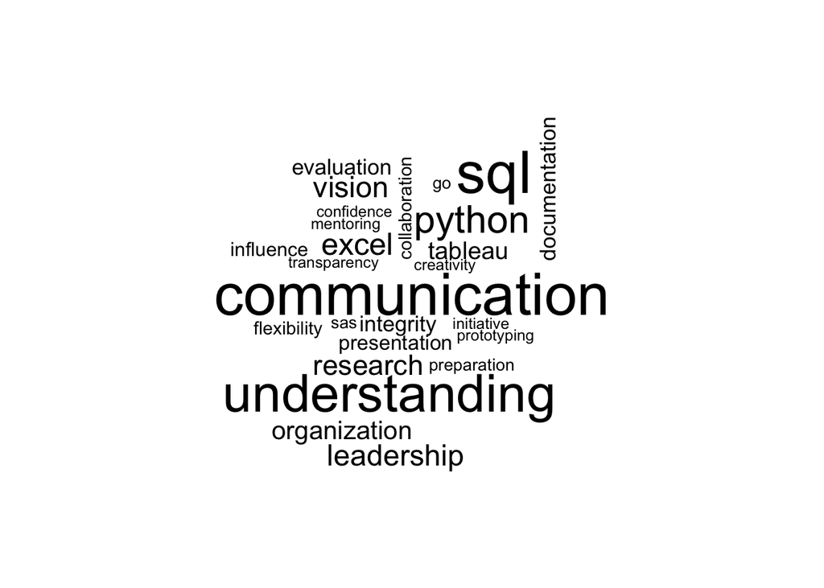

```r
library(wordcloud)
wordcloud(words = skills_count$word, freq = skills_count$n, min.freq = 2, scale = c(3, .67))
```

In the next section, we’ll confirm this is no anomoly; soft skills are extremely desirable for data science-related jobs.

### Part 2: Considering all postings

In this section, we are identifying the most frequently occurring skills across all data science jobs.

```r
# Apply the function to all jobs, creating a new column with the extracted skills
ds_jobs$skills <- sapply(ds_jobs$description, extract_skills, USE.NAMES = FALSE)

# Create a dataset with skills from all data science jobs
all_skills <- ds_jobs %>%
  unnest_tokens(word, skills) %>%
  count(word, sort = TRUE)

head(all_skills, 20)
```

```
##             word   n
## 1  communication 164
## 2  understanding 142
## 3            sql 101
## 4     leadership  89
## 5       research  69
## 6   organization  60
## 7         python  57
## 8  documentation  49
## 9         vision  43
## 10         excel  35
## 11     integrity  34
## 12  presentation  26
## 13 collaboration  23
## 14     influence  23
## 15   flexibility  22
## 16            go  18
## 17    initiative  17
## 18    evaluation  16
## 19    networking  16
## 20       tableau  16
```

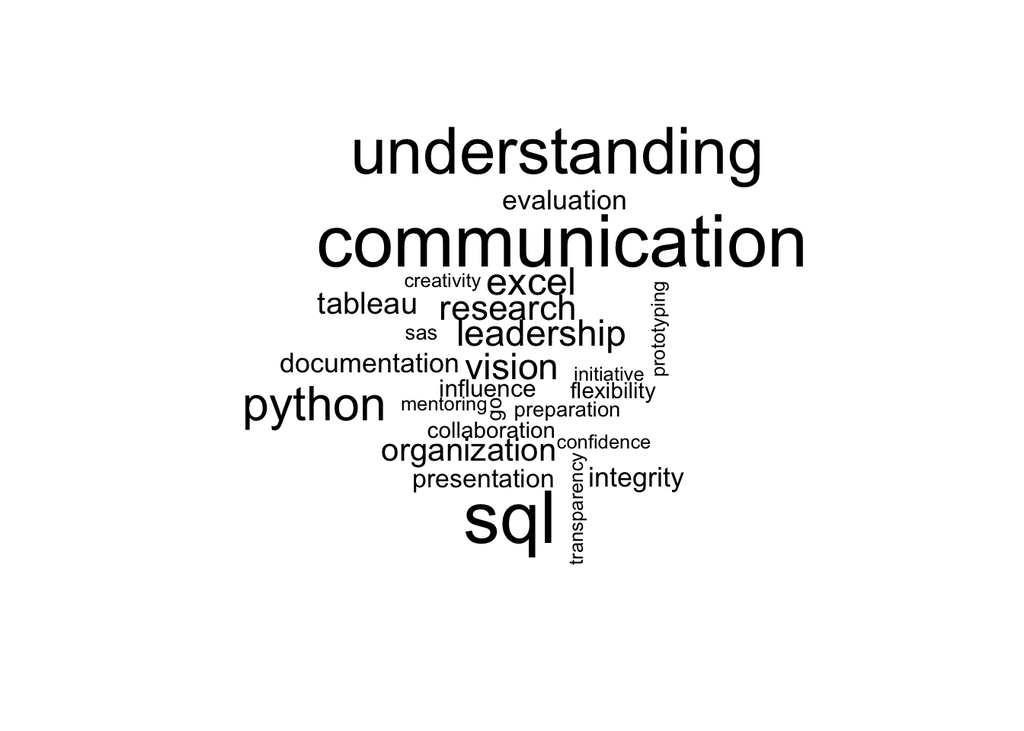

```r
library(wordcloud)
wordcloud(words = skills_count$word, freq = skills_count$n, min.freq = 2, scale = c(3, .67))
```

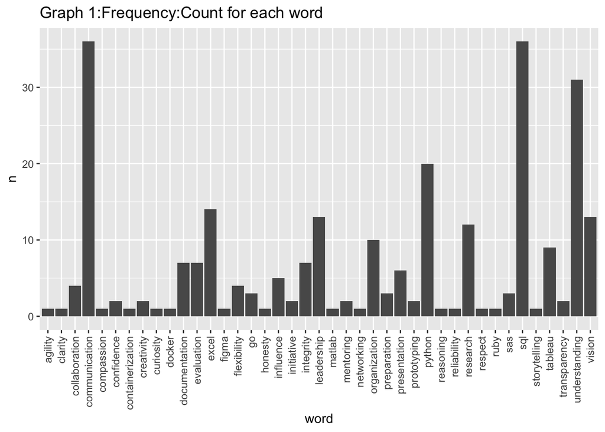

```r
library(ggplot2)
ggplot(skills_count, aes(x=word, y = n))+
  geom_bar(stat = "identity")+
  theme(axis.text.x = element_text(angle = 90, vjust = 0.5, hjust=1))+
  ggtitle("Graph 1:Frequency:Count for each word")
```

Order factors by order in the data frame

```r
skills_count$word = factor(skills_count$word,levels = unique(skills_count$word))
```

Check the dataframe

```r
library(psych)
head(skills_count)
```

```
##            word  n
## 1 communication 36
## 2           sql 36
## 3 understanding 31
## 4        python 20
## 5         excel 14
## 6    leadership 13
```

```r
tail(skills_count)
```

```
##            word n
## 36   networking 1
## 37    reasoning 1
## 38  reliability 1
## 39      respect 1
## 40         ruby 1
## 41 storytelling 1
```

```r
str(skills_count)
```

```
## 'data.frame':    41 obs. of  2 variables:
##  $ word: Factor w/ 41 levels "communication",..: 1 2 3 4 5 6 7 8 9 10 ...
##  $ n   : int  36 36 31 20 14 13 13 12 10 9 ...
```

```r
summary(skills_count)
```

```
##             word          n
##  communication: 1   Min.   : 1.000
##  sql          : 1   1st Qu.: 1.000
##  understanding: 1   Median : 2.000
##  python       : 1   Mean   : 6.585
##  excel        : 1   3rd Qu.: 7.000
##  leadership   : 1   Max.   :36.000
##  (Other)      :35
```

[figure not shown]

```r
library(lattice)
histogram(~ n | word, data = skills_count, layout= c(1,41))
```

This is a histogram of the count for each word side-by-side but horitzonal instead of vertical.Visiually we can wee the words that high count vs low and those that have similar count. This is al alternate was for us to visualize the distribution of soft skills mentioned

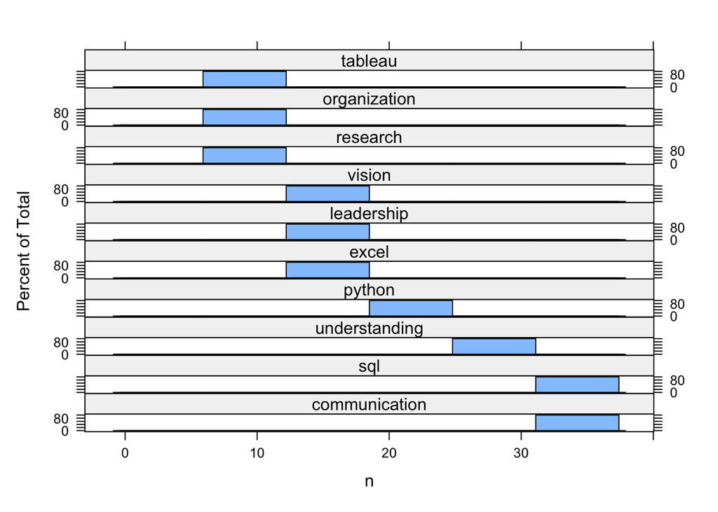

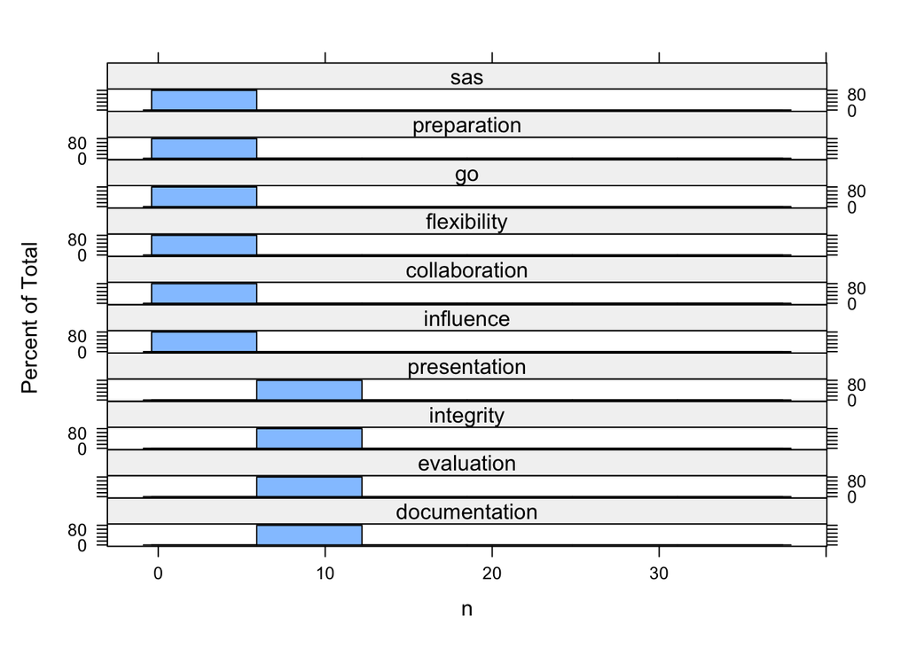

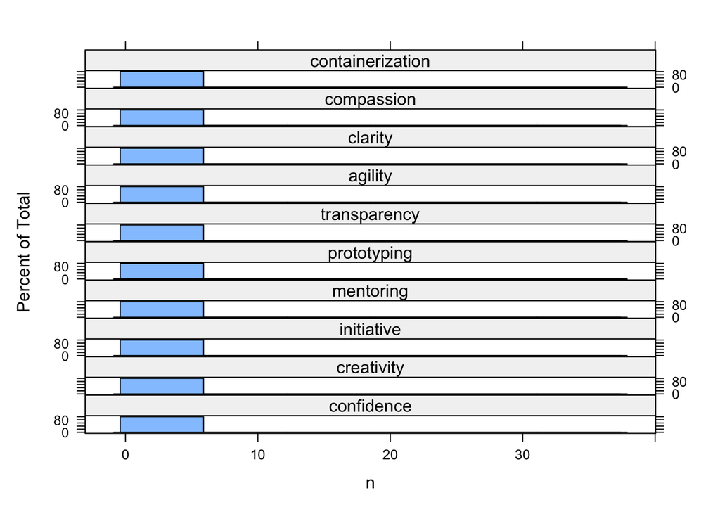

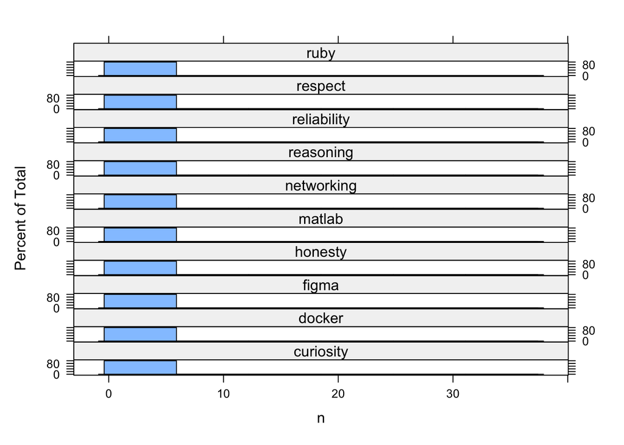

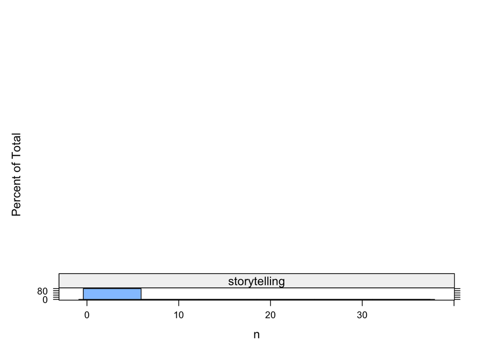

```r
library(lattice)
histogram(~ n | word, data = skills_count, layout= c(1,10))
```

## Conclusion and recommendations

- **Recommendations**: A larger sample size that cross analyzes the count of each word with the average salary for all the jobs that contained that skill would be interesting. However, a more simpler version would just be getting a bigger sample size and cross-analyzing for low level positions vs high level positions. We could probably run a Chi-Square test and see if there are observed differences for skills needed for low level positions vs more experienced/high level positions. In terms of the field of data science, the graphs suggest that there is a desire for growth [within companies] and overall for self improvement. Passing down knowledge in a field that’s very creative would require more than just basic memory skill.Data science is not a one-track field. We conclude that training or classes in social psychology would help current and upcoming scientists gain and refine skill needed to working environment and collaborative projects